# HW2

Author

Yi Wang

1. (7 points) Find the top 10 most popular destinations in the flights data. How many flights went to each

   ```r
   library(nycflights13)
   library(dplyr)
   top10_dests <- flights %>%
     count(dest, sort = TRUE) %>%
     slice_max(n, n = 10)

   print(top10_dests)
   ```

   ```
   # A tibble: 10 × 2
      dest      n
      <chr> <int>
    1 ORD   17283
    2 ATL   17215
    3 LAX   16174
    4 BOS   15508
    5 MCO   14082
    6 CLT   14064
    7 SFO   13331
    8 FLL   12055
    9 MIA   11728
   10 DCA    9705
   ```

2. (10 points) Create two new categorical variables in `flights` based on the departure time (`dep_time`), and arrival time (`arr_time`). These new variables should have four categories: “early morning” for 12am to 6am, “morning” for 6am to 12pm, “afternoon” for 12pm to 6pm, and “evening” for 6pm to 12am. Show barplots of both of these new variables. What percentage of flights were “red eye” flights? We’ll define these as flights that depart in “afternoon” or “evening” and arrive in “early morning” or “morning.”

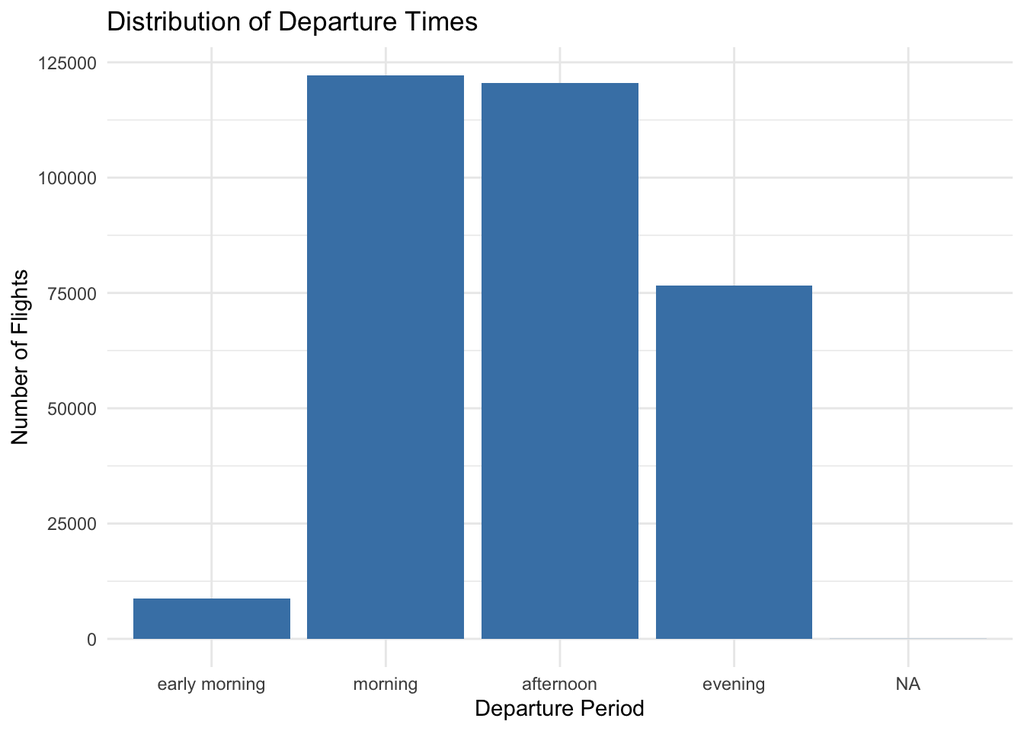

   ```r
   library(nycflights13)
   library(dplyr)
   library(ggplot2)

   flights_q2 <- flights %>%
     filter(!is.na(dep_time), !is.na(arr_time)) %>%
     mutate(
       dep_time_cat = case_when(
         dep_time < 600  ~ "early morning",
         dep_time < 1200 ~ "morning",
         dep_time < 1800 ~ "afternoon",
         dep_time < 2400 ~ "evening",
         TRUE ~ NA_character_
       ),
       arr_time_cat = case_when(
         arr_time < 600  ~ "early morning",
         arr_time < 1200 ~ "morning",
         arr_time < 1800 ~ "afternoon",
         arr_time < 2400 ~ "evening",
         TRUE ~ NA_character_
       )
     ) %>%
     mutate(

       dep_time_cat = factor(dep_time_cat,
                             levels = c("early morning","morning","afternoon","evening")),
       arr_time_cat = factor(arr_time_cat,
                             levels = c("early morning","morning","afternoon","evening"))
     )


   ggplot(flights_q2, aes(x = dep_time_cat)) +
     geom_bar(fill = "steelblue") +
     labs(title = "Distribution of Departure Times",
          x = "Departure Period", y = "Number of Flights") +
     theme_minimal()
   ```

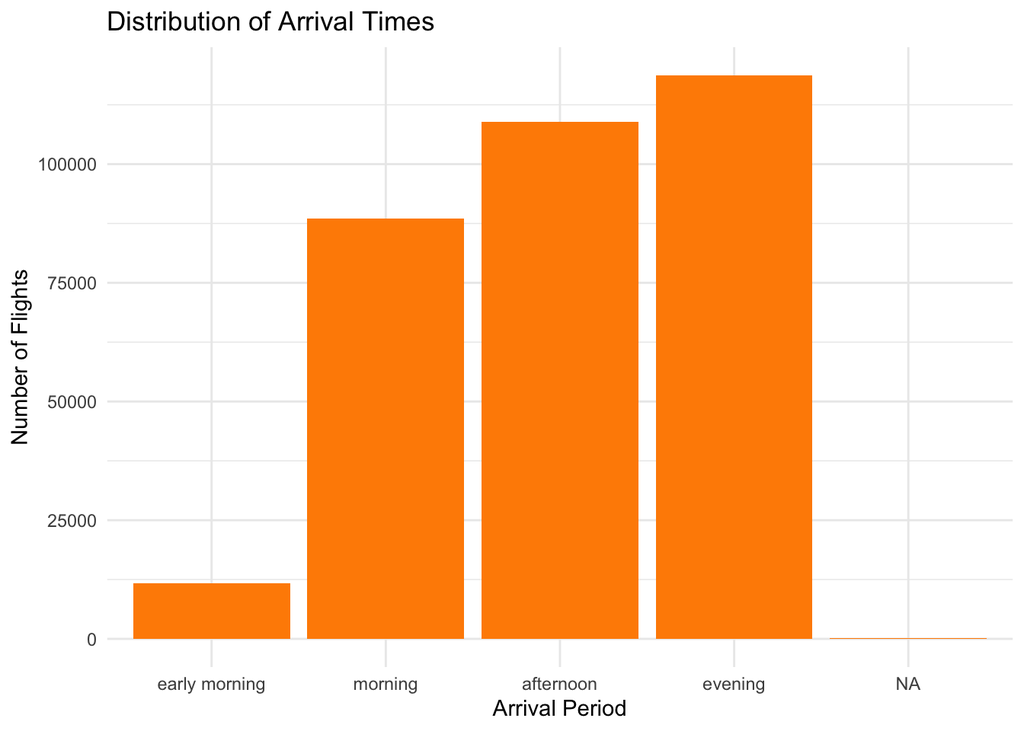

   ```r
   ggplot(flights_q2, aes(x = arr_time_cat)) +
     geom_bar(fill = "darkorange") +
     labs(title = "Distribution of Arrival Times",
          x = "Arrival Period", y = "Number of Flights") +
     theme_minimal()
   ```

   ```r
   redeye_summary <- flights_q2 %>%
     mutate(
       is_redeye = (dep_time_cat %in% c("afternoon","evening")) &
                   (arr_time_cat %in% c("early morning","morning"))
     ) %>%
     summarise(
       redeye_n   = sum(is_redeye, na.rm = TRUE),
       denom_n    = n(),
       redeye_pct = redeye_n / denom_n
     )


   redeye_summary
   ```

   ```
   # A tibble: 1 × 3
     redeye_n denom_n redeye_pct
        <int>   <int>      <dbl>
   1    10604  328063     0.0323
   ```

   ```r
   paste0("Red-eye flights: ", redeye_summary$redeye_n,
          " / ", redeye_summary$denom_n,
          " = ", round(100 * redeye_summary$redeye_pct, 2), "%")
   ```

   ```
   [1] "Red-eye flights: 10604 / 328063 = 3.23%"
   ```

   3.23% of the flights are red-eye.
3. Where there any planes that flew for multiple airlines? If so, how many were there and which airlines did they fly for?

   ```r
   pairs <- flights %>%
     filter(!is.na(tailnum), !is.na(carrier)) %>%
     distinct(tailnum, carrier)
   pairs_named <- pairs %>%
     left_join(airlines, by = "carrier")
   multi_planes <- pairs_named %>%
     group_by(tailnum) %>%
     summarise(
       n_carriers   = n_distinct(carrier),
       carriers     = paste(sort(unique(carrier)), collapse = ", "),
       carrier_names = paste(sort(unique(name)), collapse = " | "),
       .groups = "drop"
     ) %>%
     filter(n_carriers > 1) %>%
     arrange(desc(n_carriers), tailnum)

   n_planes <- nrow(multi_planes)
   n_planes
   ```

   ```
   [1] 17
   ```

   ```r
   multi_planes
   ```

   ```
   # A tibble: 17 × 4
      tailnum n_carriers carriers carrier_names
      <chr>        <int> <chr>    <chr>
    1 N146PQ           2 9E, EV   Endeavor Air Inc. | ExpressJet Airlines Inc.
    2 N153PQ           2 9E, EV   Endeavor Air Inc. | ExpressJet Airlines Inc.
    3 N176PQ           2 9E, EV   Endeavor Air Inc. | ExpressJet Airlines Inc.
    4 N181PQ           2 9E, EV   Endeavor Air Inc. | ExpressJet Airlines Inc.
    5 N197PQ           2 9E, EV   Endeavor Air Inc. | ExpressJet Airlines Inc.
    6 N200PQ           2 9E, EV   Endeavor Air Inc. | ExpressJet Airlines Inc.
    7 N228PQ           2 9E, EV   Endeavor Air Inc. | ExpressJet Airlines Inc.
    8 N232PQ           2 9E, EV   Endeavor Air Inc. | ExpressJet Airlines Inc.
    9 N933AT           2 DL, FL   AirTran Airways Corporation | Delta Air Lines In…
   10 N935AT           2 DL, FL   AirTran Airways Corporation | Delta Air Lines In…
   11 N977AT           2 DL, FL   AirTran Airways Corporation | Delta Air Lines In…
   12 N978AT           2 DL, FL   AirTran Airways Corporation | Delta Air Lines In…
   13 N979AT           2 DL, FL   AirTran Airways Corporation | Delta Air Lines In…
   14 N981AT           2 DL, FL   AirTran Airways Corporation | Delta Air Lines In…
   15 N989AT           2 DL, FL   AirTran Airways Corporation | Delta Air Lines In…
   16 N990AT           2 DL, FL   AirTran Airways Corporation | Delta Air Lines In…
   17 N994AT           2 DL, FL   AirTran Airways Corporation | Delta Air Lines In…
   ```

   Each weather observation is recorded at a specific airport identified by its origin code, which corresponds to the faa field in the airports dataset.  
   In the diagram, this should be represented as: weather.origin → airports.faa.

   For the rest of this assignment, the primary question you should keep in mind is this:

> Which weather phenomena have the most impact on flight delays?

Don’t try to answer it now, but use this question to guide your exploratory data analysis.

5. (7 points) In order to address our primary question, we want to prepare a tidy dataset (a single data frame). This will consist of information from the `flights` and `weather` data. The `year`, `month`, `day`, `hour`, and `origin` variables from `weather` provide *almost* enough information to give each observation a unique value. Create a new variable in the weather dataset by pasting together those 5 variables, then determine how many duplicated values there are and explain why.

Now merge the `flights` data and the `weather` data so that each flight contains information about the weather at its **departure airport** at the time it was **scheduled** to take off. You’ll want to use the variables `time_hour` and `origin` in order to do this.

```r
weather_keyed <- weather %>%
mutate(idx = paste(year, month, day, hour, origin, sep = "_"))

dup_n <- sum(duplicated(weather_keyed$idx))
dup_n
```

```
[1] 3
```

```r
weather_dups <- weather_keyed %>%
group_by(idx) %>%
filter(n() > 1) %>%
arrange(idx)

weather_dups %>% ungroup() %>% count(idx, sort = TRUE) %>% head()
```

```
# A tibble: 3 × 2
  idx                 n
  <chr>           <int>
1 2013_11_3_1_EWR     2
2 2013_11_3_1_JFK     2
3 2013_11_3_1_LGA     2
```

```r
fl_weather <- flights %>%
left_join(weather %>% select(origin, time_hour, temp, dewp, humid, wind_dir, wind_speed, wind_gust,
precip, pressure, visib),
by = c("origin", "time_hour"))

fl_weather %>% summarize(across(c(temp:visib), ~mean(is.na(.x)))) %>% t()
```

```
                  [,1]
temp       0.004670760
dewp       0.004670760
humid      0.004670760
wind_dir   0.029087583
wind_speed 0.004851890
wind_gust  0.761310188
precip     0.004620282
pressure   0.115174478
visib      0.004620282
```

We found 3 duplicated keys, all occurring on 2013-11-03 at 01:00 for EWR, JFK, and LGA.This is explained by the end of Daylight Saving Time (fall-back), which causes the 1am hour to occur twice, so multiple weather observations share the same (year, month, day, hour, origin) combination.

6. (20 points) On this merged dataset, perform steps 2-5 of the EDA checklist presented in class. Remember the context provided by our primary question above.

   ```r
   dim(fl_weather)
   ```

   ```
   [1] 336776     28
   ```

   ```r
   nrow(fl_weather)
   ```

   ```
   [1] 336776
   ```

   ```r
   ncol(fl_weather)
   ```

   ```
   [1] 28
   ```

   ```r
   str(fl_weather)
   ```

   ```
   tibble [336,776 × 28] (S3: tbl_df/tbl/data.frame)
    $ year          : int [1:336776] 2013 2013 2013 2013 2013 2013 2013 2013 2013 2013 ...
    $ month         : int [1:336776] 1 1 1 1 1 1 1 1 1 1 ...
    $ day           : int [1:336776] 1 1 1 1 1 1 1 1 1 1 ...
    $ dep_time      : int [1:336776] 517 533 542 544 554 554 555 557 557 558 ...
    $ sched_dep_time: int [1:336776] 515 529 540 545 600 558 600 600 600 600 ...
    $ dep_delay     : num [1:336776] 2 4 2 -1 -6 -4 -5 -3 -3 -2 ...
    $ arr_time      : int [1:336776] 830 850 923 1004 812 740 913 709 838 753 ...
    $ sched_arr_time: int [1:336776] 819 830 850 1022 837 728 854 723 846 745 ...
    $ arr_delay     : num [1:336776] 11 20 33 -18 -25 12 19 -14 -8 8 ...
    $ carrier       : chr [1:336776] "UA" "UA" "AA" "B6" ...
    $ flight        : int [1:336776] 1545 1714 1141 725 461 1696 507 5708 79 301 ...
    $ tailnum       : chr [1:336776] "N14228" "N24211" "N619AA" "N804JB" ...
    $ origin        : chr [1:336776] "EWR" "LGA" "JFK" "JFK" ...
    $ dest          : chr [1:336776] "IAH" "IAH" "MIA" "BQN" ...
    $ air_time      : num [1:336776] 227 227 160 183 116 150 158 53 140 138 ...
    $ distance      : num [1:336776] 1400 1416 1089 1576 762 ...
    $ hour          : num [1:336776] 5 5 5 5 6 5 6 6 6 6 ...
    $ minute        : num [1:336776] 15 29 40 45 0 58 0 0 0 0 ...
    $ time_hour     : POSIXct[1:336776], format: "2013-01-01 05:00:00" "2013-01-01 05:00:00" ...
    $ temp          : num [1:336776] 39 39.9 39 39 39.9 ...
    $ dewp          : num [1:336776] 28 25 27 27 25 ...
    $ humid         : num [1:336776] 64.4 54.8 61.6 61.6 54.8 ...
    $ wind_dir      : num [1:336776] 260 250 260 260 260 260 240 260 260 260 ...
    $ wind_speed    : num [1:336776] 12.7 15 15 15 16.1 ...
    $ wind_gust     : num [1:336776] NA 21.9 NA NA 23 ...
    $ precip        : num [1:336776] 0 0 0 0 0 0 0 0 0 0 ...
    $ pressure      : num [1:336776] 1012 1011 1012 1012 1012 ...
    $ visib         : num [1:336776] 10 10 10 10 10 10 10 10 10 10 ...
   ```

   ```r
   summary(fl_weather)
   ```

   ```
         year          month             day           dep_time    sched_dep_time
    Min.   :2013   Min.   : 1.000   Min.   : 1.00   Min.   :   1   Min.   : 106
    1st Qu.:2013   1st Qu.: 4.000   1st Qu.: 8.00   1st Qu.: 907   1st Qu.: 906
    Median :2013   Median : 7.000   Median :16.00   Median :1401   Median :1359
    Mean   :2013   Mean   : 6.549   Mean   :15.71   Mean   :1349   Mean   :1344
    3rd Qu.:2013   3rd Qu.:10.000   3rd Qu.:23.00   3rd Qu.:1744   3rd Qu.:1729
    Max.   :2013   Max.   :12.000   Max.   :31.00   Max.   :2400   Max.   :2359
                                                    NA's   :8255
      dep_delay          arr_time    sched_arr_time   arr_delay
    Min.   : -43.00   Min.   :   1   Min.   :   1   Min.   : -86.000
    1st Qu.:  -5.00   1st Qu.:1104   1st Qu.:1124   1st Qu.: -17.000
    Median :  -2.00   Median :1535   Median :1556   Median :  -5.000
    Mean   :  12.64   Mean   :1502   Mean   :1536   Mean   :   6.895
    3rd Qu.:  11.00   3rd Qu.:1940   3rd Qu.:1945   3rd Qu.:  14.000
    Max.   :1301.00   Max.   :2400   Max.   :2359   Max.   :1272.000
    NA's   :8255      NA's   :8713                  NA's   :9430
      carrier              flight       tailnum             origin
    Length:336776      Min.   :   1   Length:336776      Length:336776
    Class :character   1st Qu.: 553   Class :character   Class :character
    Mode  :character   Median :1496   Mode  :character   Mode  :character
                       Mean   :1972
                       3rd Qu.:3465
                       Max.   :8500

        dest              air_time        distance         hour
    Length:336776      Min.   : 20.0   Min.   :  17   Min.   : 1.00
    Class :character   1st Qu.: 82.0   1st Qu.: 502   1st Qu.: 9.00
    Mode  :character   Median :129.0   Median : 872   Median :13.00
                       Mean   :150.7   Mean   :1040   Mean   :13.18
                       3rd Qu.:192.0   3rd Qu.:1389   3rd Qu.:17.00
                       Max.   :695.0   Max.   :4983   Max.   :23.00
                       NA's   :9430
        minute        time_hour                           temp
    Min.   : 0.00   Min.   :2013-01-01 05:00:00.00   Min.   : 10.94
    1st Qu.: 8.00   1st Qu.:2013-04-04 13:00:00.00   1st Qu.: 42.08
    Median :29.00   Median :2013-07-03 10:00:00.00   Median : 57.20
    Mean   :26.23   Mean   :2013-07-03 05:22:54.64   Mean   : 57.00
    3rd Qu.:44.00   3rd Qu.:2013-10-01 07:00:00.00   3rd Qu.: 71.96
    Max.   :59.00   Max.   :2013-12-31 23:00:00.00   Max.   :100.04
                                                     NA's   :1573
         dewp           humid           wind_dir       wind_speed
    Min.   :-9.94   Min.   : 12.74   Min.   :  0.0   Min.   : 0.000
    1st Qu.:26.06   1st Qu.: 43.99   1st Qu.:130.0   1st Qu.: 6.905
    Median :42.80   Median : 57.73   Median :220.0   Median :10.357
    Mean   :41.63   Mean   : 59.56   Mean   :201.5   Mean   :11.114
    3rd Qu.:57.92   3rd Qu.: 75.33   3rd Qu.:290.0   3rd Qu.:14.960
    Max.   :78.08   Max.   :100.00   Max.   :360.0   Max.   :42.579
    NA's   :1573    NA's   :1573     NA's   :9796    NA's   :1634
      wind_gust          precip          pressure          visib
    Min.   :16.11    Min.   :0.0000   Min.   : 983.8   Min.   : 0.000
    1st Qu.:20.71    1st Qu.:0.0000   1st Qu.:1012.7   1st Qu.:10.000
    Median :24.17    Median :0.0000   Median :1017.5   Median :10.000
    Mean   :25.25    Mean   :0.0046   Mean   :1017.8   Mean   : 9.256
    3rd Qu.:28.77    3rd Qu.:0.0000   3rd Qu.:1022.8   3rd Qu.:10.000
    Max.   :66.75    Max.   :1.2100   Max.   :1042.1   Max.   :10.000
    NA's   :256391   NA's   :1556     NA's   :38788    NA's   :1556
   ```

   ```r
   head(fl_weather, 5)
   ```

   ```
   # A tibble: 5 × 28
      year month   day dep_time sched_dep_time dep_delay arr_time sched_arr_time
     <int> <int> <int>    <int>          <int>     <dbl>    <int>          <int>
   1  2013     1     1      517            515         2      830            819
   2  2013     1     1      533            529         4      850            830
   3  2013     1     1      542            540         2      923            850
   4  2013     1     1      544            545        -1     1004           1022
   5  2013     1     1      554            600        -6      812            837
   # ℹ 20 more variables: arr_delay <dbl>, carrier <chr>, flight <int>,
   #   tailnum <chr>, origin <chr>, dest <chr>, air_time <dbl>, distance <dbl>,
   #   hour <dbl>, minute <dbl>, time_hour <dttm>, temp <dbl>, dewp <dbl>,
   #   humid <dbl>, wind_dir <dbl>, wind_speed <dbl>, wind_gust <dbl>,
   #   precip <dbl>, pressure <dbl>, visib <dbl>
   ```

   ```r
   tail(fl_weather, 5)
   ```

   ```
   # A tibble: 5 × 28
      year month   day dep_time sched_dep_time dep_delay arr_time sched_arr_time
     <int> <int> <int>    <int>          <int>     <dbl>    <int>          <int>
   1  2013     9    30       NA           1455        NA       NA           1634
   2  2013     9    30       NA           2200        NA       NA           2312
   3  2013     9    30       NA           1210        NA       NA           1330
   4  2013     9    30       NA           1159        NA       NA           1344
   5  2013     9    30       NA            840        NA       NA           1020
   # ℹ 20 more variables: arr_delay <dbl>, carrier <chr>, flight <int>,
   #   tailnum <chr>, origin <chr>, dest <chr>, air_time <dbl>, distance <dbl>,
   #   hour <dbl>, minute <dbl>, time_hour <dttm>, temp <dbl>, dewp <dbl>,
   #   humid <dbl>, wind_dir <dbl>, wind_speed <dbl>, wind_gust <dbl>,
   #   precip <dbl>, pressure <dbl>, visib <dbl>
   ```

   ```r
   table(fl_weather$origin)
   ```

   ```
      EWR    JFK    LGA
   120835 111279 104662
   ```

   ```r
   head(select(fl_weather, origin, time_hour, temp, precip, wind_speed, visib))
   ```

   ```
   # A tibble: 6 × 6
     origin time_hour            temp precip wind_speed visib
     <chr>  <dttm>              <dbl>  <dbl>      <dbl> <dbl>
   1 EWR    2013-01-01 05:00:00  39.0      0       12.7    10
   2 LGA    2013-01-01 05:00:00  39.9      0       15.0    10
   3 JFK    2013-01-01 05:00:00  39.0      0       15.0    10
   4 JFK    2013-01-01 05:00:00  39.0      0       15.0    10
   5 LGA    2013-01-01 06:00:00  39.9      0       16.1    10
   6 EWR    2013-01-01 05:00:00  39.0      0       12.7    10
   ```

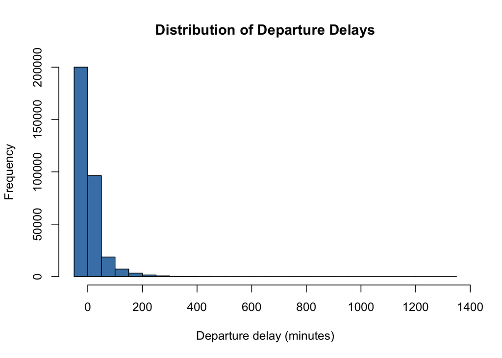

   ```r
   hist(fl_weather$dep_delay,
        main = "Distribution of Departure Delays",
        xlab = "Departure delay (minutes)", col = "steelblue")
   ```

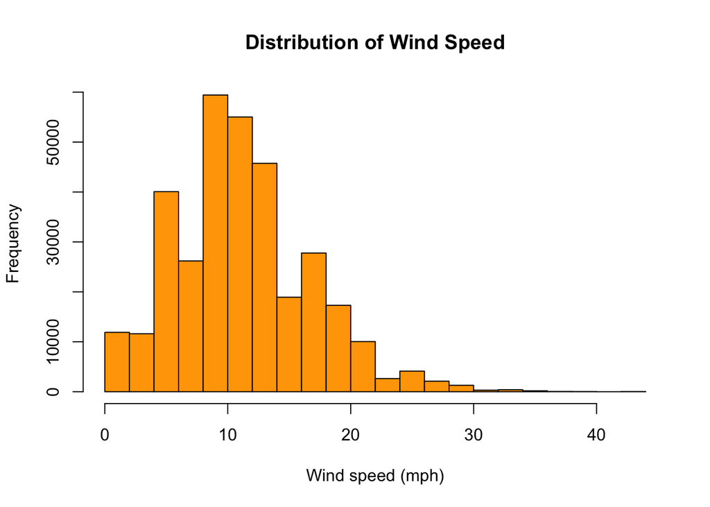

   ```r
   hist(fl_weather$wind_speed,
        main = "Distribution of Wind Speed",
        xlab = "Wind speed (mph)", col = "orange")
   ```

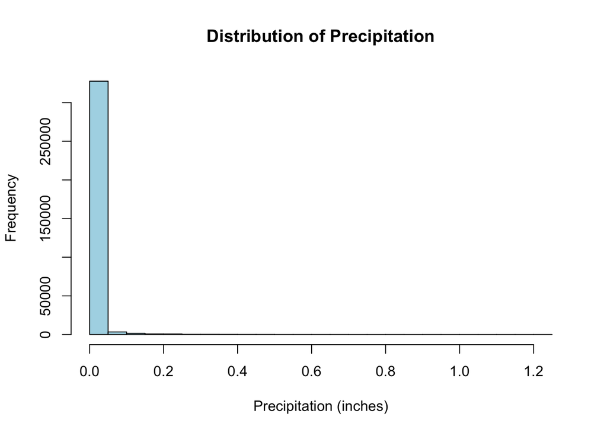

   ```r
   hist(fl_weather$precip,
        main = "Distribution of Precipitation",
        xlab = "Precipitation (inches)", col = "lightblue")
   ```

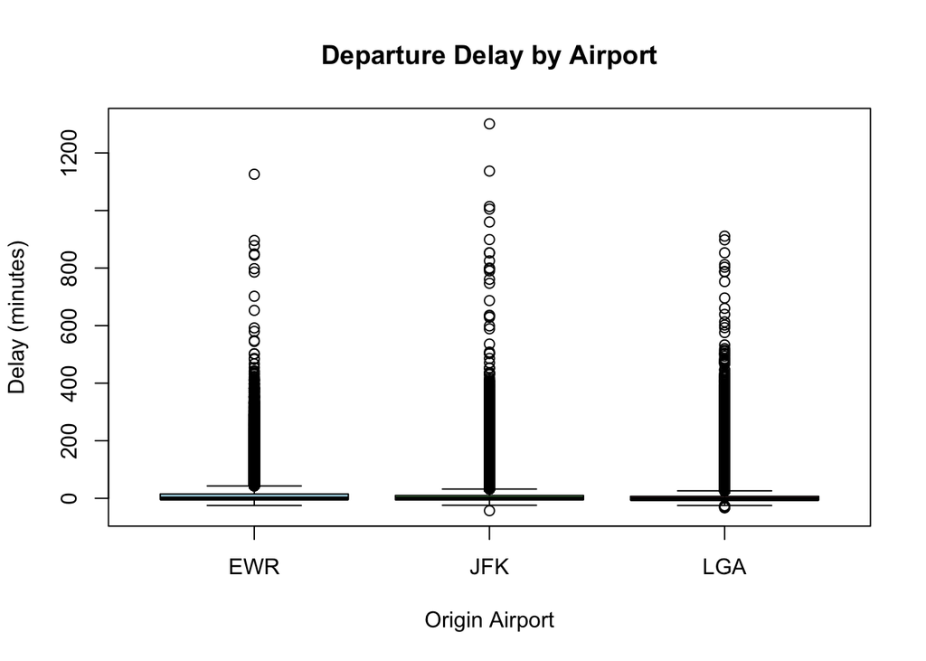

   ```r
   boxplot(fl_weather$dep_delay ~ fl_weather$origin,
           main = "Departure Delay by Airport",
           xlab = "Origin Airport", ylab = "Delay (minutes)",
           col = c("lightblue", "lightgreen", "lightpink"))
   ```

   The distribution of departure delays is highly right-skewed, showing that most flights depart on time or with only minor delays, while a small number of flights experience extreme delays over 200 minutes.  
   Wind speed generally ranges from 0 to 20 mph, with most values between 4–14 mph, indicating that strong winds are relatively rare.  
   Precipitation is concentrated near zero, suggesting that most flights occur under clear conditions with little or no rainfall.  
   The boxplot of departure delays by airport shows similar patterns across EWR, JFK, and LGA, although JFK displays slightly greater variability, possibly due to heavier traffic.  
   Overall, these results indicate that flight delays are typically short and infrequent, but adverse weather events such as high wind or precipitation can increase the likelihood and magnitude of delays.
7. (15 points) Calculate the average departure delay for each **day** (Hint: think about which variables you need in order to do this!). Which day had the worst average length of delay for departures? Now calculate the averages by **day** and **origin**. Which airport had the worst single day for delays and when was it? Now calculate the averages by **hour** and **origin**. Which airport had the worst single hour for delays (and when was it)?

   ```r
   library(dplyr)
   library(lubridate)
   fl_weather <- fl_weather %>% filter(!is.na(dep_delay))

   daily_delay <- fl_weather %>%
     group_by(year, month, day) %>%
     summarise(avg_dep_delay = mean(dep_delay, na.rm = TRUE), .groups = "drop") %>%
     arrange(desc(avg_dep_delay))

   worst_day <- daily_delay %>% slice_max(avg_dep_delay, n = 1)
   worst_day
   ```

   ```
   # A tibble: 1 × 4
      year month   day avg_dep_delay
     <int> <int> <int>         <dbl>
   1  2013     3     8          83.5
   ```

   ```r
   daily_origin_delay <- fl_weather %>%
     group_by(year, month, day, origin) %>%
     summarise(avg_dep_delay = mean(dep_delay, na.rm = TRUE), .groups = "drop") %>%
     arrange(desc(avg_dep_delay))

   worst_day_origin <- daily_origin_delay %>% slice_max(avg_dep_delay, n = 1)
   worst_day_origin
   ```

   ```
   # A tibble: 1 × 5
      year month   day origin avg_dep_delay
     <int> <int> <int> <chr>          <dbl>
   1  2013     3     8 LGA             106.
   ```

   ```r
   hourly_origin_delay <- fl_weather %>%
     group_by(year, month, day, hour, origin) %>%
     summarise(avg_dep_delay = mean(dep_delay, na.rm = TRUE), .groups = "drop") %>%
     arrange(desc(avg_dep_delay))

   worst_hour_origin <- hourly_origin_delay %>% slice_max(avg_dep_delay, n = 1)
   worst_hour_origin
   ```

   ```
   # A tibble: 1 × 6
      year month   day  hour origin avg_dep_delay
     <int> <int> <int> <dbl> <chr>          <dbl>
   1  2013     7    28    21 LGA             280.
   ```

   The daily analysis revealed that March 8 had the longest average departure delay, reaching 83.54 minutes.  
   Examining delays by both day and airport, the worst case was recorded at LGA on March 8, where flights were delayed an average of 105.72 minutes.  
   On a finer time scale, the worst single-hour delay occurred at LGA on July 28 at 9 PM, with an average delay of 279.67 minutes, indicating a severe congestion or weather event during that time.
8. (7 points) Compute the average delay by destination, then add that information to the `airports` data frame. Make a map showing the spatial distribution of delays (you can make it however you like, but we recommend using either `ggplot` or `leaflet`). Use the color of the points to display the average delay for each airport.

   ```r
   library(dplyr)
   library(leaflet)
   library(viridis)
   library(nycflights13)

   avg_by_dest <- flights %>%
     filter(!is.na(arr_delay)) %>%
     group_by(dest) %>%
     summarise(
       avg_arr_delay = mean(arr_delay, na.rm = TRUE),
       n = n(),
       .groups = "drop"
     ) %>%
     left_join(airports, by = c("dest" = "faa")) %>%
     filter(!is.na(lat), !is.na(lon))

   pal <- colorNumeric("viridis", domain = avg_by_dest$avg_arr_delay)

   leaflet(avg_by_dest) %>%
     addProviderTiles(providers$CartoDB.Positron) %>%
     addCircleMarkers(
       lng = ~lon, lat = ~lat,
       radius = ~pmax(3, pmin(10, sqrt(n)/15)),
       fillColor = ~pal(avg_arr_delay),
       color = "black", weight = 0.3,
       fillOpacity = 0.9,
       popup = ~paste0(
         "<b>", name, "</b><br>",
         "Avg Arrival Delay: ", round(avg_arr_delay, 1), " min<br>",
         "Flights: ", n
       )
     ) %>%
     addLegend(
       "bottomright",
       pal = pal, values = ~avg_arr_delay,
       title = "Avg Arrival Delay (min)",
       opacity = 1
     )
   ```

[interactive chart not shown]

9. (20 points) Finally, create as many plots and summary statistics as needed to answer the primary question above.

```r
library(dplyr)
library(ggplot2)
library(tidyr)
library(broom)

#1. Correlation Analysis
data <- fl_weather %>%
  filter(!is.na(dep_delay), !is.na(arr_delay)) %>%
  select(dep_delay, arr_delay, temp, dewp, humid,
         wind_speed, wind_gust, precip, pressure, visib)

# Departure delay correlations
dep_corr <- data %>%
  summarise(across(temp:visib, ~cor(dep_delay, .x, use = "complete.obs"))) %>%
  tidyr::pivot_longer(everything(), names_to = "Variable", values_to = "DepDelay_Corr")

# Arrival delay correlations
arr_corr <- data %>%
  summarise(across(temp:visib, ~cor(arr_delay, .x, use = "complete.obs"))) %>%
  tidyr::pivot_longer(everything(), names_to = "Variable", values_to = "ArrDelay_Corr")
```

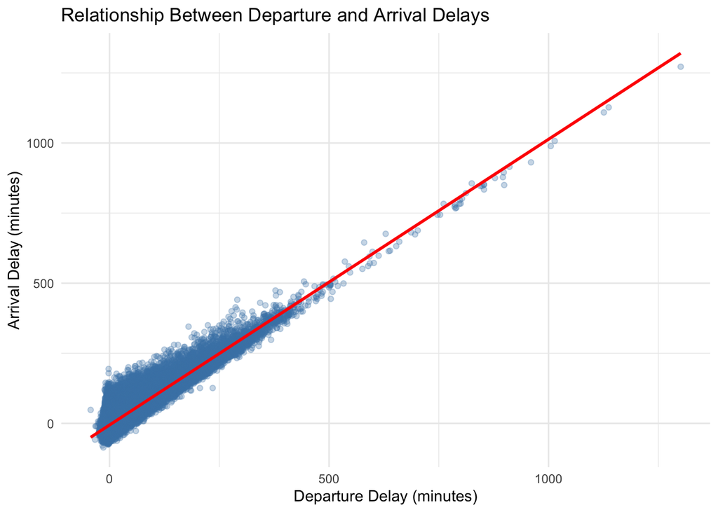

```r
#2. Relationship Between Departure and Arrival Delays
ggplot(data, aes(x = dep_delay, y = arr_delay)) +
  geom_point(alpha = 0.3, color = "steelblue") +
  geom_smooth(method = "lm", color = "red") +
  labs(title = "Relationship Between Departure and Arrival Delays",
       x = "Departure Delay (minutes)",
       y = "Arrival Delay (minutes)") +
  theme_minimal()
```

```r
cor(data$dep_delay, data$arr_delay, use = "complete.obs")
```

```
[1] 0.9148028
```

The points cluster closely along the red line, suggesting a strong positive linear relationship. The correlation coefficient (r = 0.91) confirms this strong relationship — when a flight departs late, it almost always arrives late as well.

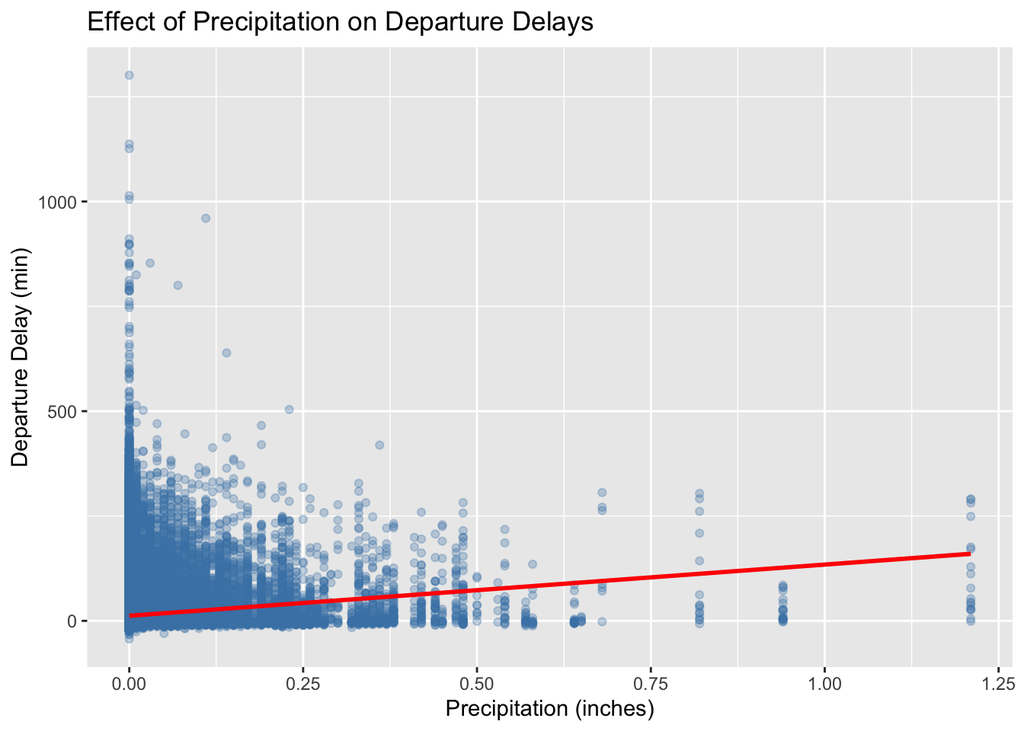

```r
#3. Visual Exploration of Weather Effects
#Precipitation
ggplot(data, aes(x = precip, y = dep_delay)) +
  geom_point(alpha = 0.3, color = "steelblue") +
  geom_smooth(method = "lm", color = "red") +
  labs(title = "Effect of Precipitation on Departure Delays",
       x = "Precipitation (inches)", y = "Departure Delay (min)")
```

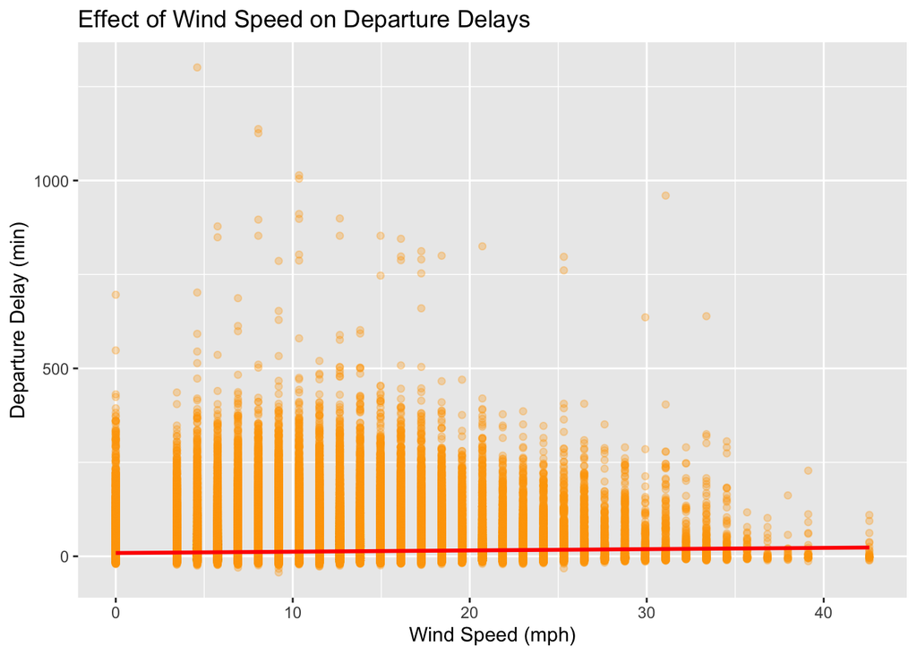

```r
#Wind Speed
ggplot(data, aes(x = wind_speed, y = dep_delay)) +
  geom_point(alpha = 0.3, color = "orange") +
  geom_smooth(method = "lm", color = "red") +
  labs(title = "Effect of Wind Speed on Departure Delays",
       x = "Wind Speed (mph)", y = "Departure Delay (min)")
```

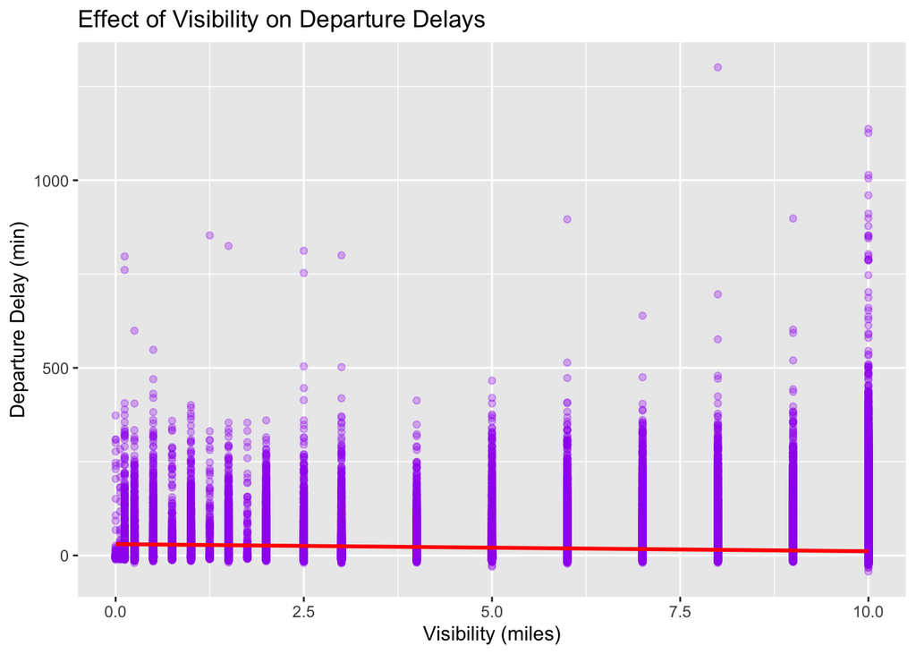

```r
#Visibility
ggplot(data, aes(x = visib, y = dep_delay)) +
  geom_point(alpha = 0.3, color = "purple") +
  geom_smooth(method = "lm", color = "red") +
  labs(title = "Effect of Visibility on Departure Delays",
       x = "Visibility (miles)", y = "Departure Delay (min)")
```

The scatter plot shows a **positive relationship** between precipitation and departure delays.

Rain and snow slightly contribute to longer departure delays, but precipitation alone is not a strong predictor.

Wind speed alone does not have a major effect on departure delays, though extreme winds might still cause cancellations or holding patterns.

Low visibility can occasionally cause severe delays, but under normal conditions, visibility does not strongly influence departure time.

Across all three factors, **precipitation** shows the most noticeable (but still weak) effect on departure delays.  
Wind speed and visibility appear to have minimal influence in this dataset, implying that other factors—such as air traffic, airline operations, and congestion—may play larger roles in determining flight delays.

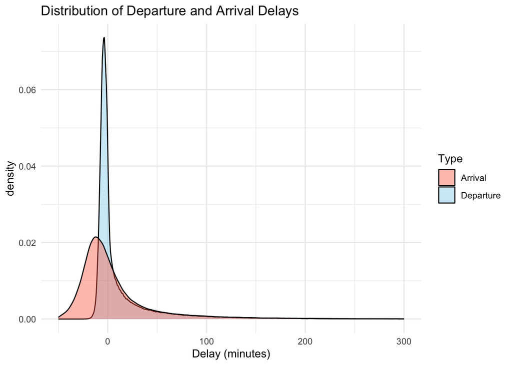

```r
ggplot(data) +
  geom_density(aes(x = dep_delay, fill = "Departure"), alpha = 0.4) +
  geom_density(aes(x = arr_delay, fill = "Arrival"), alpha = 0.4) +
  scale_fill_manual(values = c("Departure" = "skyblue", "Arrival" = "tomato")) +
  xlim(-50, 300) +
  labs(title = "Distribution of Departure and Arrival Delays",
       x = "Delay (minutes)", fill = "Type") +
  theme_minimal()
```

This density plot compares the distributions of **departure delays** (blue) and **arrival delays** (red).

While both departure and arrival delays follow a similar skewed pattern, arrival delays tend to be slightly shorter on average, showing airlines’ partial recovery capability during flight.

```r
#4. Comparison of Delay Distributions
data_bins <- data %>%
  mutate(
    precip_bin = cut(precip, breaks = c(-Inf, 0, 0.1, 0.5, Inf),
                     labels = c("0", "(0,0.1]", "(0.1,0.5]", ">0.5")),
    wind_bin   = cut(wind_speed, breaks = c(-Inf, 5, 10, 15, 20, Inf),
                     labels = c("<=5","(5,10]","(10,15]","(15,20]",">20")),
    visib_bin  = cut(visib, breaks = c(-Inf, 2, 5, 10, Inf),
                     labels = c("<=2","(2,5]","(5,10]"," >10"))
  )

# Mean dep_delay by bins
bin_summary <- list(
  precip = data_bins %>% group_by(precip_bin) %>%
    summarise(mean_delay = mean(dep_delay, na.rm = TRUE), n = n(), .groups = "drop"),
  wind   = data_bins %>% group_by(wind_bin) %>%
    summarise(mean_delay = mean(dep_delay, na.rm = TRUE), n = n(), .groups = "drop"),
  visib  = data_bins %>% group_by(visib_bin) %>%
    summarise(mean_delay = mean(dep_delay, na.rm = TRUE), n = n(), .groups = "drop")
)
bin_summary
```

```
$precip
# A tibble: 5 × 3
  precip_bin mean_delay      n
  <fct>           <dbl>  <int>
1 0                11.3 304877
2 (0,0.1]          28.6  17251
3 (0.1,0.5]        40.5   3552
4 >0.5             48.9    139
5 <NA>             13.4   1527

$wind
# A tibble: 6 × 3
  wind_bin mean_delay      n
  <fct>         <dbl>  <int>
1 <=5            10.2  40552
2 (5,10]         11.2 105252
3 (10,15]        13.0 116608
4 (15,20]        14.8  43412
5 >20            16.8  19917
6 <NA>           13.0   1605

$visib
# A tibble: 4 × 3
  visib_bin mean_delay      n
  <fct>          <dbl>  <int>
1 <=2             27.8   9681
2 (2,5]           20.7  12270
3 (5,10]          11.7 303868
4 <NA>            13.4   1527
```

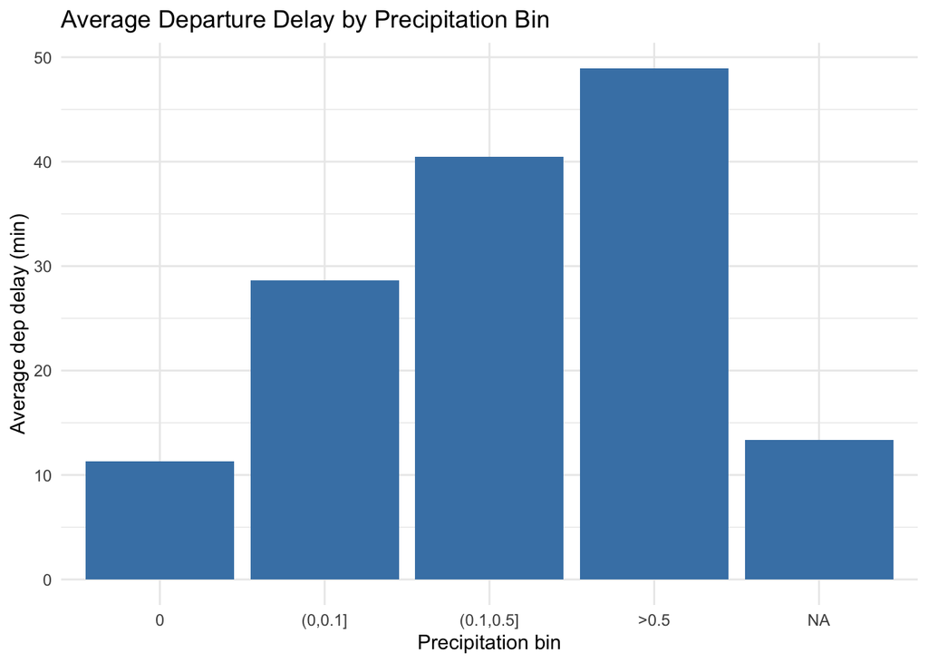

```r
# Bar plots for bins
ggplot(bin_summary$precip, aes(precip_bin, mean_delay)) +
  geom_col(fill = "steelblue") +
  labs(title = "Average Departure Delay by Precipitation Bin",
       x = "Precipitation bin", y = "Average dep delay (min)") +
  theme_minimal()
```

Precipitation has a **clear positive effect** on departure delays — heavier rainfall is strongly associated with longer delays, likely due to runway and visibility issues.

Strong winds contribute moderately to delays, possibly due to takeoff/landing safety protocols, but the effect is not dramatic.

Together, these patterns confirm that **adverse weather conditions directly contribute to longer departure delays**.